# Approximating the Future

#### Jonah Williams

**In an era of big and messy data, traditional statistics cannot give us the answers we need.** This is not an inner-disciplinary fight between frequentists and bayesians, nor is it a condemnation of the p-value or statistical significance. The truth of the matter is that the focus of academic statistics is different than the needs of business analysis; Where the former is concerned with theory and proof, the latter should be concerned with making practical models to forecast, explain, and discover. If you are given a model with $p < 0.05$, then it's predictions must be fairly accurate, right?

**Staistical Significance doesn't mean what you've been led to believe**. The common (mis)interpretation goes as follows: If I have $p < 0.05$ then that means I've controlled my false positive rate and my model has less than a 5% chance of being incorrect. Unfortunately there are enough caveats on the above to make it basically unworkable for the purpose its been used. First, P-values in no way account for false negatives, which can be potentially much worse depending on the context of the model. Second, the actual formulation of a P-value is $P(D \ | \ H)$, the probability of generating data under the hypothesis. Our P-value is really telling us about our data, not the model at all! It depends entirely on how well our residual error conform to a well known distribution, and it is trival to get significant p-values with statistical sleight-of-hand and larger samples. Finally, all along we've been using the idea of "how well does this model fit" to try and get at a deeper question: *How good our my predictions?*

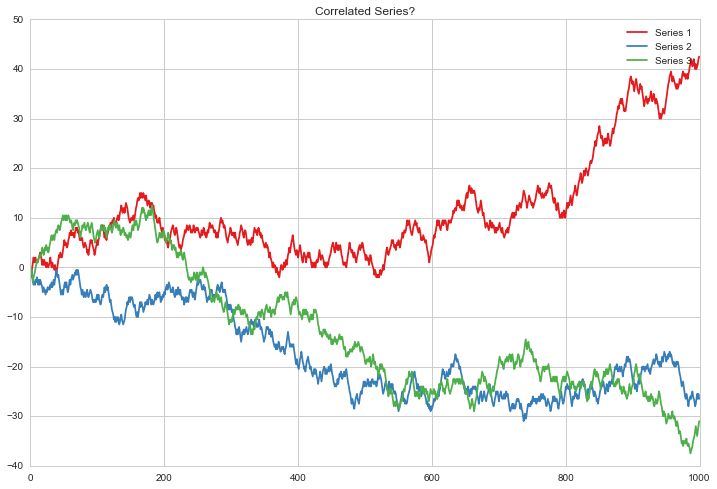

```python
import pandas as pd
import numpy as np
import matplotlib.pyplot as plt
import seaborn as sns
%matplotlib inline

np.random.seed(100) # For Reproducibility!
a = np.random.choice([-1,-0.5,0.5, 1], size=1000, replace=True)
b = np.random.choice([-1,-0.5,0.5, 1], size=1000, replace=True)
c = np.random.choice([-1,-0.5,0.5, 1], size=1000, replace=True)

sns.set_style("whitegrid")
plt.figure(figsize=(12, 8))
plt.plot(np.cumsum(a), color="#e41a1c", label="Series 1")
plt.plot(np.cumsum(b), color="#377eb8", label="Series 2")
plt.plot(np.cumsum(c), color="#4daf4a", label="Series 3")
plt.title("Correlated Series?")
plt.legend()
plt.show()
```

```python
import statsmodels.api as sm
X = np.cumsum(b)
y = np.cumsum(c)
X = sm.add_constant(X)
mod = sm.OLS(y, X)
res = mod.fit()
print res.summary()
```

```
                            OLS Regression Results
==============================================================================
Dep. Variable:                      y   R-squared:                       0.743
Model:                            OLS   Adj. R-squared:                  0.743
Method:                 Least Squares   F-statistic:                     2882.
Date:                Mon, 04 May 2015   Prob (F-statistic):          1.66e-296
Time:                        15:21:11   Log-Likelihood:                -3310.2
No. Observations:                1000   AIC:                             6624.
Df Residuals:                     998   BIC:                             6634.
Df Model:                           1
Covariance Type:            nonrobust
==============================================================================
                 coef    std err          t      P>|t|      [95.0% Conf. Int.]
------------------------------------------------------------------------------
const          9.2596      0.464     19.960      0.000         8.349    10.170
x1             1.2832      0.024     53.682      0.000         1.236     1.330
==============================================================================
Omnibus:                       23.802   Durbin-Watson:                   0.037
Prob(Omnibus):                  0.000   Jarque-Bera (JB):               23.321
Skew:                          -0.340   Prob(JB):                     8.63e-06
Kurtosis:                       2.689   Cond. No.                         43.0
==============================================================================

Warnings:
[1] Standard Errors assume that the covariance matrix of the errors is correctly specified.
```

A low p-values, high R-squared, everything we could hope for. Unforunately in this case we can peak behind the curtain: the correlation is just a result of cumulative series. While in this case it is easy to identify the source of the problem, real data is much messier. Rather than trying to identify and name all the possible situations that can give pathological models, wouldn't it be nice if we had a simple way to protect ourselves?

**It is possible to estimate our average out-of-sample error.** Using the PAC (Probably Approximately Correct) learning framework, we can bound our error with some probability $1 - \alpha$ (that's the probably part) and some tolerance $\epsilon > 0$ (and the approximate part). The setup is fairly simple; we can simulate the arrival of new data by leaving out a subset of our original data, this is known as the test set. It can be shown that the empirical error on this set approximates the "true" error of our model, plus the bounds determined by the constraints above. As an added bonus, this framework is completely agnostic to the methods used to determine the model. Whether it was a linear regression, decision tree, or SVM we can use the same procedure. The only changes that need to be made are the definitions of risk for the loss function( regression versus classification problem). PAC learning protects us from the mistakes of over-eager analysts and overfit models.

```python
from sklearn.linear_model import LinearRegression
reg = LinearRegression(fit_intercept=False)
reg.fit(X[0:-100,0::], y[0:-100])
np.mean(np.sum(np.square(reg.predict(X[-100:,0::]) - y[-100:])))
```

```
17302.927032383675
```

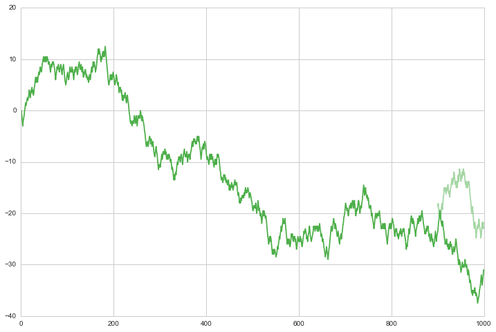

```python
plt.figure(figsize=(12, 8))
plt.plot(range(len(a) - 100, len(a)), reg.predict(X[-100:,0::]),
         color="#4daf4a", label="predictions", alpha=0.5)
plt.plot(np.cumsum(c), color="#4daf4a", label="Series 3")
plt.show()
```

$$ R(h) \leq 17302.927 + \sqrt \frac{log \frac{2}{\delta}}{2m} $$$$ R(h) \leq 17302.927 + \sqrt \frac{log \frac{2}{0.1}}{200} $$$$ R(h) \leq 17303.049$$